# Workshop 6 Solutions: What Regression Is For

FEV lung function, age, height, and smoking

GRAPH Courses team

2026-06-24

# Introduction

This solutions file is a full worked version of `rsr_week_06_fev_workshop.Rmd`. It keeps the blank student prompts visible, then gives solution code and written answers.

# Load packages and data

```r
if (!require(pacman)) install.packages("pacman")
pacman::p_load(tidyverse, here, broom)
```

```r
fev <- read_csv(here("data/fev_kahn.csv"))
glimpse(fev)
```

```
## Rows: 654
## Columns: 5
## $ age_yrs   <dbl> 9, 8, 7, 9, 9, 8, 6, 6, 8, 9, 6, 8, 8, 8, 8, 7, 5, 6, 9, 9, …
## $ fev_l     <dbl> 1.708, 1.724, 1.720, 1.558, 1.895, 2.336, 1.919, 1.415, 1.98…
## $ height_in <dbl> 57.0, 67.5, 54.5, 53.0, 57.0, 61.0, 58.0, 56.0, 58.5, 60.0, …
## $ sex       <chr> "female", "female", "female", "male", "male", "female", "fem…
## $ smoke     <chr> "non_smoker", "non_smoker", "non_smoker", "non_smoker", "non…
```

**Checkpoint answer:** `fev` has **654 rows and 5 columns**.

# Part 1: Describe a relationship with age

This part was already fully worked in the student file.

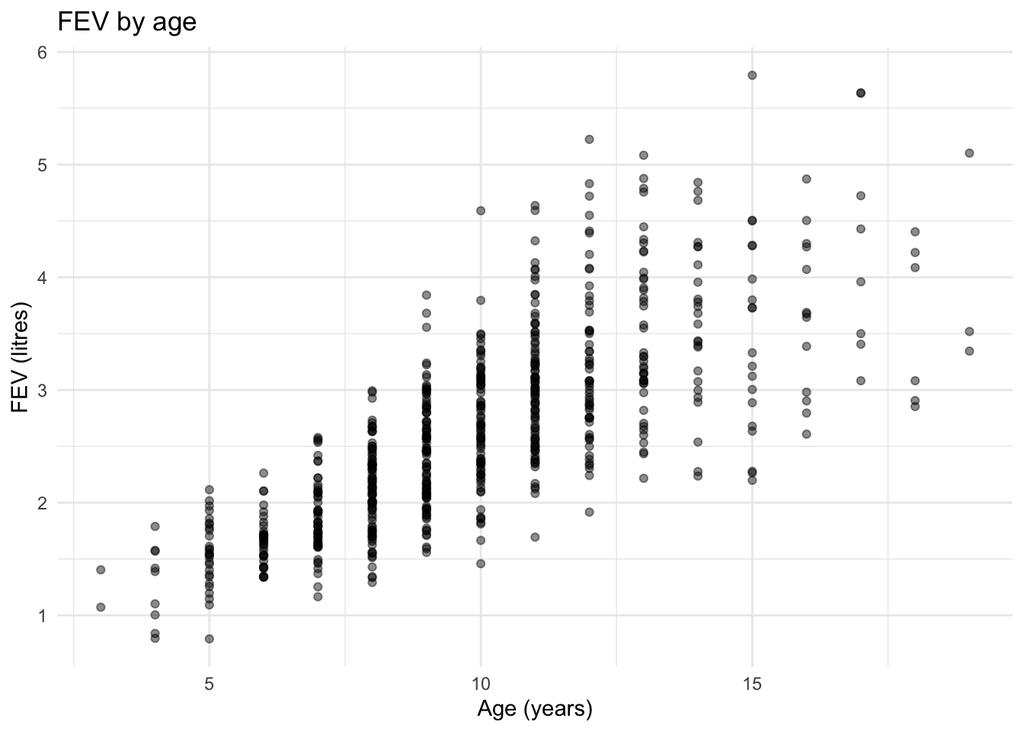

```r
ggplot(fev, aes(x = age_yrs, y = fev_l)) +
  geom_point(alpha = 0.45) +
  labs(
    title = "FEV by age",
    x = "Age (years)",
    y = "FEV (litres)"
  ) +
  theme_minimal()
```

```r
r_age_fev <- cor(fev$age_yrs, fev$fev_l)
r_age_fev
```

```
## [1] 0.756459
```

```r
age_model <- lm(fev_l ~ age_yrs, data = fev)
summary(age_model)
```

```
##
## Call:
## lm(formula = fev_l ~ age_yrs, data = fev)
##
## Residuals:
##      Min       1Q   Median       3Q      Max
## -1.57539 -0.34567 -0.04989  0.32124  2.12786
##
## Coefficients:
##             Estimate Std. Error t value Pr(>|t|)
## (Intercept) 0.431648   0.077895   5.541 4.36e-08 ***
## age_yrs     0.222041   0.007518  29.533  < 2e-16 ***
## ---
## Signif. codes:  0 '***' 0.001 '**' 0.01 '*' 0.05 '.' 0.1 ' ' 1
##
## Residual standard error: 0.5675 on 652 degrees of freedom
## Multiple R-squared:  0.5722, Adjusted R-squared:  0.5716
## F-statistic: 872.2 on 1 and 652 DF,  p-value: < 2.2e-16
```

```r
tidy(age_model)
```

```
## # A tibble: 2 × 5
##   term        estimate std.error statistic   p.value
##   <chr>          <dbl>     <dbl>     <dbl>     <dbl>
## 1 (Intercept)    0.432   0.0779       5.54 4.36e-  8
## 2 age_yrs        0.222   0.00752     29.5  2.45e-122
```

```r
glance(age_model)
```

```
## # A tibble: 1 × 12
##   r.squared adj.r.squared sigma statistic   p.value    df logLik   AIC   BIC
##       <dbl>         <dbl> <dbl>     <dbl>     <dbl> <dbl>  <dbl> <dbl> <dbl>
## 1     0.572         0.572 0.568      872. 2.45e-122     1  -557. 1119. 1132.
## # ℹ 3 more variables: deviance <dbl>, df.residual <int>, nobs <int>
```

```r
r_age_fev^2
```

```
## [1] 0.5722302
```

# Part 2: Fit a better predictor: height

Student prompt:

```r
ggplot(fev, aes(x = ____________, y = ____________)) +
  geom_point(alpha = 0.45) +
  labs(
    title = "FEV by height",
    x = "Height (inches)",
    y = "FEV (litres)"
  ) +
  theme_minimal()
```

Solution:

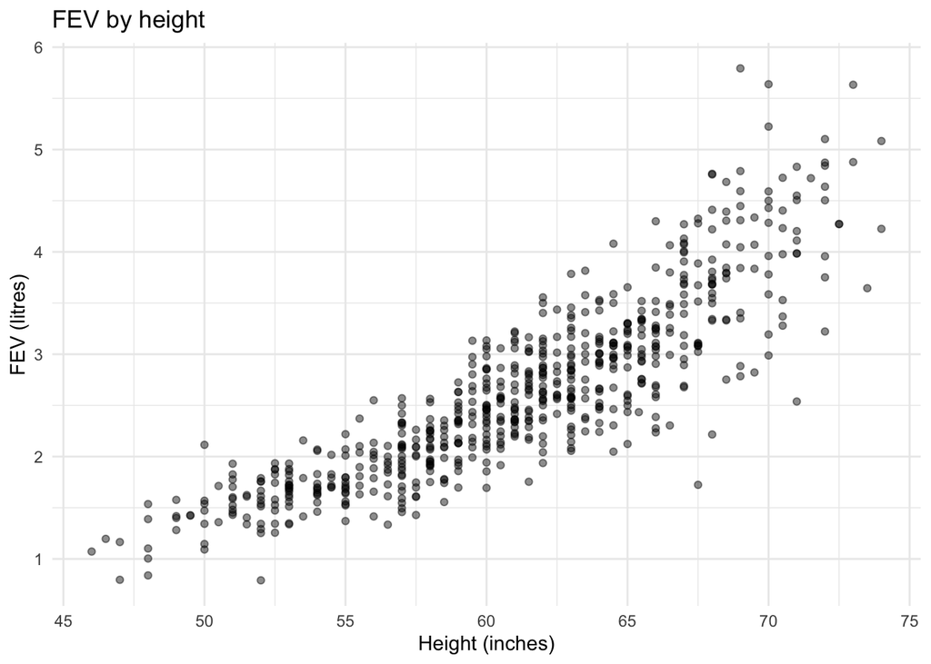

```r
ggplot(fev, aes(x = height_in, y = fev_l)) +
  geom_point(alpha = 0.45) +
  labs(
    title = "FEV by height",
    x = "Height (inches)",
    y = "FEV (litres)"
  ) +
  theme_minimal()
```

**Q2a answer:** The relationship is positive.

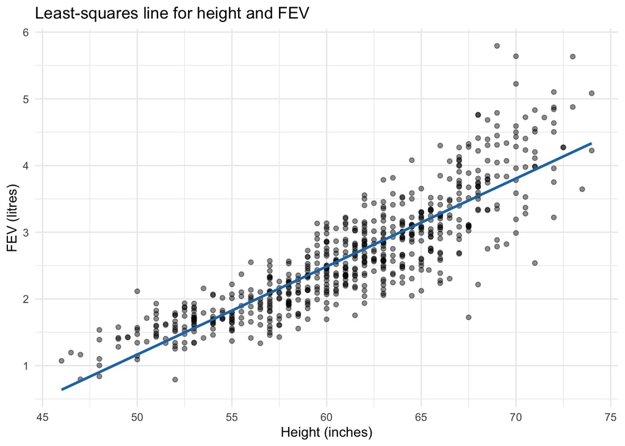

```r
ggplot(fev, aes(x = height_in, y = fev_l)) +
  geom_point(alpha = 0.45) +
  geom_smooth(method = "lm", se = FALSE, color = "#1f78b4") +
  labs(
    title = "Least-squares line for height and FEV",
    x = "Height (inches)",
    y = "FEV (litres)"
  ) +
  theme_minimal()
```

Student prompt:

```r
r_height_fev <- cor(fev$__________, fev$__________)
r_height_fev
```

Solution:

```r
r_height_fev <- cor(fev$height_in, fev$fev_l)
r_height_fev
```

```
## [1] 0.868135
```

**Q2b answer:** The correlation is about **0.868**. This relationship is **positive** and **strong**.

Student prompt:

```r
height_model <- lm(__________ ~ __________, data = fev)
summary(height_model)
```

Solution:

```r
height_model <- lm(fev_l ~ height_in, data = fev)
summary(height_model)
```

```
##
## Call:
## lm(formula = fev_l ~ height_in, data = fev)
##
## Residuals:
##      Min       1Q   Median       3Q      Max
## -1.75167 -0.26619 -0.00401  0.24474  2.11936
##
## Coefficients:
##              Estimate Std. Error t value Pr(>|t|)
## (Intercept) -5.432679   0.181460  -29.94   <2e-16 ***
## height_in    0.131976   0.002955   44.66   <2e-16 ***
## ---
## Signif. codes:  0 '***' 0.001 '**' 0.01 '*' 0.05 '.' 0.1 ' ' 1
##
## Residual standard error: 0.4307 on 652 degrees of freedom
## Multiple R-squared:  0.7537, Adjusted R-squared:  0.7533
## F-statistic:  1995 on 1 and 652 DF,  p-value: < 2.2e-16
```

Student prompt:

```r
tidy(__________)
```

Solution:

```r
tidy(height_model)
```

```
## # A tibble: 2 × 5
##   term        estimate std.error statistic   p.value
##   <chr>          <dbl>     <dbl>     <dbl>     <dbl>
## 1 (Intercept)   -5.43    0.181       -29.9 1.45e-124
## 2 height_in      0.132   0.00295      44.7 1.57e-200
```

**Q2c answer:**

$$\widehat{FEV} = -5.43 + 0.132 \times
height$$

**Q2d answer:** For each additional 1 inch of height, predicted FEV is higher by about **0.132 litres**, on average.

**Q2e answer:** The p-value for `height_in` is about `1.57e-200`, far below 0.05. We reject the null hypothesis.

Student prompt:

```r
glance(__________)
```

Solution:

```r
glance(height_model)
```

```
## # A tibble: 1 × 12
##   r.squared adj.r.squared sigma statistic   p.value    df logLik   AIC   BIC
##       <dbl>         <dbl> <dbl>     <dbl>     <dbl> <dbl>  <dbl> <dbl> <dbl>
## 1     0.754         0.753 0.431     1995. 1.57e-200     1  -376.  758.  772.
## # ℹ 3 more variables: deviance <dbl>, df.residual <int>, nobs <int>
```

**Q2f answer:** About **75.4%** of the variation in FEV is explained by **height** in this simple linear regression.

**Q2g answer:** Height gives the better one-variable model. Its R-squared is about 0.754, higher than the age model’s R-squared of about 0.572.

# Part 3: Predict with the height model

Student prompt:

```r
new_youth <- tibble(height_in = 60)
predict(__________, newdata = __________)
```

Solution:

```r
new_youth <- tibble(height_in = 60)
predict(height_model, newdata = new_youth)
```

```
##        1
## 2.485855
```

**Q3a answer:** The predicted FEV for a youth who is 60 inches tall is about **2.49 litres**.

Student prompt:

```r
fev_with_height_model <- augment(height_model, data = fev)

fev_with_height_model %>%
  select(height_in, fev_l, .fitted, .resid) %>%
  head()
```

Solution:

```r
fev_with_height_model <- augment(height_model, data = fev)

fev_with_height_model %>%
  select(height_in, fev_l, .fitted, .resid) %>%
  head()
```

```
## # A tibble: 6 × 4
##   height_in fev_l .fitted   .resid
##       <dbl> <dbl>   <dbl>    <dbl>
## 1      57    1.71    2.09 -0.382
## 2      67.5  1.72    3.48 -1.75
## 3      54.5  1.72    1.76 -0.0400
## 4      53    1.56    1.56 -0.00403
## 5      57    1.90    2.09 -0.195
## 6      61    2.34    2.62 -0.282
```

**Q3b answer:** A positive residual means the observed FEV is above the fitted line.

# Part 4: Smoking, age, and why control can matter

```r
fev %>%
  group_by(smoke) %>%
  summarise(
    n = n(),
    mean_age = mean(age_yrs),
    mean_height = mean(height_in),
    mean_fev = mean(fev_l),
    .groups = "drop"
  )
```

```
## # A tibble: 2 × 5
##   smoke          n mean_age mean_height mean_fev
##   <chr>      <int>    <dbl>       <dbl>    <dbl>
## 1 non_smoker   589     9.53        60.6     2.57
## 2 smoker        65    13.5         66.0     3.28
```

**Q4a answer:** Smokers have higher mean FEV in the raw summary.

**Q4b answer:** Smokers are older on average.

```r
smoke_raw_model <- lm(fev_l ~ smoke, data = fev)
tidy(smoke_raw_model)
```

```
## # A tibble: 2 × 5
##   term        estimate std.error statistic   p.value
##   <chr>          <dbl>     <dbl>     <dbl>     <dbl>
## 1 (Intercept)    2.57     0.0347     74.0  1.49e-319
## 2 smokesmoker    0.711    0.110       6.46 1.99e- 10
```

```r
glance(smoke_raw_model)
```

```
## # A tibble: 1 × 12
##   r.squared adj.r.squared sigma statistic  p.value    df logLik   AIC   BIC
##       <dbl>         <dbl> <dbl>     <dbl>    <dbl> <dbl>  <dbl> <dbl> <dbl>
## 1    0.0602        0.0588 0.841      41.8 1.99e-10     1  -814. 1634. 1647.
## # ℹ 3 more variables: deviance <dbl>, df.residual <int>, nobs <int>
```

```r
smoke_height_model <- lm(fev_l ~ height_in + smoke, data = fev)
tidy(smoke_height_model)
```

```
## # A tibble: 3 × 5
##   term        estimate std.error statistic   p.value
##   <chr>          <dbl>     <dbl>     <dbl>     <dbl>
## 1 (Intercept) -5.43      0.188     -28.9   5.41e-119
## 2 height_in    0.132     0.00308    42.8   1.93e-191
## 3 smokesmoker  0.00632   0.0587      0.108 9.14e-  1
```

```r
glance(smoke_height_model)
```

```
## # A tibble: 1 × 12
##   r.squared adj.r.squared sigma statistic   p.value    df logLik   AIC   BIC
##       <dbl>         <dbl> <dbl>     <dbl>     <dbl> <dbl>  <dbl> <dbl> <dbl>
## 1     0.754         0.753 0.431      996. 8.77e-199     2  -376.  760.  778.
## # ℹ 3 more variables: deviance <dbl>, df.residual <int>, nobs <int>
```

**Q4c answer:** The raw comparison was misleading because smokers in this dataset are much older and taller than non-smokers, and older/taller youths naturally have higher FEV. After controlling for height, the smoking coefficient is close to 0.